# Proesper loan analysis

## Preliminary Wrangling

> The data set consists of 113937 entries of loans and 81 columns. The main purpose of this analysis is to determine which varibles are most suitable for prediciting the Borrower annual interest rate.

```python
# import all packages and set plots to be embedded inline
import numpy as np
import pandas as pd
import matplotlib.pyplot as plt
import seaborn as sns

%matplotlib inline
```

```python
df = pd.read_csv('prosperLoanData.csv')
```

```python
pd.set_option("display.max_rows", None, "display.max_columns", None)
df.head()
```

|  | ListingKey | ListingNumber | ListingCreationDate | CreditGrade | Term | LoanStatus | ClosedDate | BorrowerAPR | BorrowerRate | LenderYield | EstimatedEffectiveYield | EstimatedLoss | EstimatedReturn | ProsperRating (numeric) | ProsperRating (Alpha) | ProsperScore | ListingCategory (numeric) | BorrowerState | Occupation | EmploymentStatus | EmploymentStatusDuration | IsBorrowerHomeowner | CurrentlyInGroup | GroupKey | DateCreditPulled | CreditScoreRangeLower | CreditScoreRangeUpper | FirstRecordedCreditLine | CurrentCreditLines | … |
| --- | --- | --- | --- | --- | --- | --- | --- | --- | --- | --- | --- | --- | --- | --- | --- | --- | --- | --- | --- | --- | --- | --- | --- | --- | --- | --- | --- | --- | --- | --- |
| 0 | 1021339766868145413AB3B | 193129 | 2007-08-26 19:09:29.263000000 | C | 36 | Completed | 2009-08-14 00:00:00 | 0.16516 | 0.1580 | 0.1380 | NaN | NaN | NaN | NaN | NaN | NaN | 0 | CO | Other | Self-employed | 2.0 | True | True | NaN | 2007-08-26 18:41:46.780000000 | 640.0 | 659.0 | 2001-10-11 00:00:00 | 5.0 | … |
| 1 | 10273602499503308B223C1 | 1209647 | 2014-02-27 08:28:07.900000000 | NaN | 36 | Current | NaN | 0.12016 | 0.0920 | 0.0820 | 0.07960 | 0.0249 | 0.05470 | 6.0 | A | 7.0 | 2 | CO | Professional | Employed | 44.0 | False | False | NaN | 2014-02-27 08:28:14 | 680.0 | 699.0 | 1996-03-18 00:00:00 | 14.0 | … |
| 2 | 0EE9337825851032864889A | 81716 | 2007-01-05 15:00:47.090000000 | HR | 36 | Completed | 2009-12-17 00:00:00 | 0.28269 | 0.2750 | 0.2400 | NaN | NaN | NaN | NaN | NaN | NaN | 0 | GA | Other | Not available | NaN | False | True | 783C3371218786870A73D20 | 2007-01-02 14:09:10.060000000 | 480.0 | 499.0 | 2002-07-27 00:00:00 | NaN | … |
| 3 | 0EF5356002482715299901A | 658116 | 2012-10-22 11:02:35.010000000 | NaN | 36 | Current | NaN | 0.12528 | 0.0974 | 0.0874 | 0.08490 | 0.0249 | 0.06000 | 6.0 | A | 9.0 | 16 | GA | Skilled Labor | Employed | 113.0 | True | False | NaN | 2012-10-22 11:02:32 | 800.0 | 819.0 | 1983-02-28 00:00:00 | 5.0 | … |
| 4 | 0F023589499656230C5E3E2 | 909464 | 2013-09-14 18:38:39.097000000 | NaN | 36 | Current | NaN | 0.24614 | 0.2085 | 0.1985 | 0.18316 | 0.0925 | 0.09066 | 3.0 | D | 4.0 | 2 | MN | Executive | Employed | 44.0 | True | False | NaN | 2013-09-14 18:38:44 | 680.0 | 699.0 | 2004-02-20 00:00:00 | 19.0 | … |

```python
df.info()
```

```
<class 'pandas.core.frame.DataFrame'>
RangeIndex: 113937 entries, 0 to 113936
Data columns (total 81 columns):
 #   Column                               Non-Null Count   Dtype
---  ------                               --------------   -----
 0   ListingKey                           113937 non-null  object
 1   ListingNumber                        113937 non-null  int64
 2   ListingCreationDate                  113937 non-null  object
 3   CreditGrade                          28953 non-null   object
 4   Term                                 113937 non-null  int64
 5   LoanStatus                           113937 non-null  object
 6   ClosedDate                           55089 non-null   object
 7   BorrowerAPR                          113912 non-null  float64
 8   BorrowerRate                         113937 non-null  float64
 9   LenderYield                          113937 non-null  float64
```

[output cut: 73 more lines]

```python
df.shape
```

```
(113937, 81)
```

### What is the structure of your dataset?

The dataset consiste of 113937 loans and 81 variables.

### What is/are the main feature(s) of interest in your dataset?

I am interested in predicting what is the annual percentage rate of the loan

### What features in the dataset do you think will help support your investigation into your feature(s) of interest?

- BorrowerAPR
- ProsperScore
- Occupation
- IncomeRange
- StatedMonthlyIncome
- LoanOriginalAmount
- AvailableBankcardCredit
- Term

```python
idf=df[['BorrowerAPR'
,
'ProsperScore'
,
'Occupation'
,
'IncomeRange'
,
'StatedMonthlyIncome'
,
'LoanOriginalAmount'
,
'AvailableBankcardCredit'
,
'Term']]
```

```python
idf.head()
```

|  | BorrowerAPR | ProsperScore | Occupation | IncomeRange | StatedMonthlyIncome | LoanOriginalAmount | AvailableBankcardCredit | Term |
| --- | --- | --- | --- | --- | --- | --- | --- | --- |
| 0 | 0.16516 | NaN | Other | $25,000-49,999 | 3083.333333 | 9425 | 1500.0 | 36 |
| 1 | 0.12016 | 7.0 | Professional | $50,000-74,999 | 6125.000000 | 10000 | 10266.0 | 36 |
| 2 | 0.28269 | NaN | Other | Not displayed | 2083.333333 | 3001 | NaN | 36 |
| 3 | 0.12528 | 9.0 | Skilled Labor | $25,000-49,999 | 2875.000000 | 10000 | 30754.0 | 36 |
| 4 | 0.24614 | 4.0 | Executive | $100,000+ | 9583.333333 | 15000 | 695.0 | 36 |

```python
idf.info()
```

```
<class 'pandas.core.frame.DataFrame'>
RangeIndex: 113937 entries, 0 to 113936
Data columns (total 8 columns):
 #   Column                   Non-Null Count   Dtype
---  ------                   --------------   -----
 0   BorrowerAPR              113912 non-null  float64
 1   ProsperScore             84853 non-null   float64
 2   Occupation               110349 non-null  object
 3   IncomeRange              113937 non-null  object
 4   StatedMonthlyIncome      113937 non-null  float64
 5   LoanOriginalAmount       113937 non-null  int64
 6   AvailableBankcardCredit  106393 non-null  float64
 7   Term                     113937 non-null  int64
dtypes: float64(4), int64(2), object(2)
memory usage: 7.0+ MB
```

```python
df.EmploymentStatus.unique()
```

```
array(['Self-employed', 'Employed', 'Not available', 'Full-time', 'Other',
       nan, 'Not employed', 'Part-time', 'Retired'], dtype=object)
```

```python
df.query('EmploymentStatus =="Not employed" ').Occupation.unique()
```

```
array(['Other', 'Student - College Graduate Student',
       'Sales - Commission', 'Student - Community College',
       'Psychologist', 'Student - College Senior',
       'Student - College Junior', 'Professional',
       'Student - College Sophomore', 'Analyst', "Teacher's Aide",
       'Retail Management', 'Homemaker', 'Sales - Retail', "Nurse's Aide",
       'Waiter/Waitress', 'Student - Technical School',
       'Student - College Freshman', 'Skilled Labor'], dtype=object)
```

```python
df.query('EmploymentStatus =="Not employed" and Occupation != Occupation ').head()
```

|  | ListingKey | ListingNumber | ListingCreationDate | CreditGrade | Term | LoanStatus | ClosedDate | BorrowerAPR | BorrowerRate | LenderYield | ... | LP_ServiceFees | LP_CollectionFees | LP_GrossPrincipalLoss | LP_NetPrincipalLoss | LP_NonPrincipalRecoverypayments | PercentFunded | Recommendations | InvestmentFromFriendsCount | InvestmentFromFriendsAmount | Investors |
| --- | --- | --- | --- | --- | --- | --- | --- | --- | --- | --- | --- | --- | --- | --- | --- | --- | --- | --- | --- | --- | --- |

0 rows × 81 columns

```python
df.query('Occupation != Occupation ').head()
```

|  | ListingKey | ListingNumber | ListingCreationDate | CreditGrade | Term | LoanStatus | ClosedDate | BorrowerAPR | BorrowerRate | LenderYield | ... | LP_ServiceFees | LP_CollectionFees | LP_GrossPrincipalLoss | LP_NetPrincipalLoss | LP_NonPrincipalRecoverypayments | PercentFunded | Recommendations | InvestmentFromFriendsCount | InvestmentFromFriendsAmount | Investors |
| --- | --- | --- | --- | --- | --- | --- | --- | --- | --- | --- | --- | --- | --- | --- | --- | --- | --- | --- | --- | --- | --- |
| 34 | 0F6C3603015887476F3F015 | 1180690 | 2014-02-24 12:55:20.430000000 | NaN | 36 | Current | NaN | 0.22966 | 0.1920 | 0.1820 | ... | 0.00 | 0.00 | 0.0 | 0.0 | 0.0 | 1.0 | 0 | 0 | 0.0 | 1 |
| 39 | 109D3366077649289619396 | 24135 | 2006-07-11 17:14:14.647000000 | B | 36 | Completed | 2009-10-22 00:00:00 | 0.15211 | 0.1450 | 0.1400 | ... | -81.40 | -299.78 | 0.0 | 0.0 | 0.0 | 1.0 | 0 | 0 | 0.0 | 44 |
| 92 | 0FE433661215082408720F0 | 22591 | 2006-07-02 11:05:02.857000000 | AA | 36 | Completed | 2007-03-01 00:00:00 | 0.08292 | 0.0755 | 0.0705 | ... | -6.73 | 0.00 | 0.0 | 0.0 | 0.0 | 1.0 | 0 | 0 | 0.0 | 21 |
| 146 | 34B03365511229087456DB5 | 31745 | 2006-08-16 09:43:10.867000000 | A | 36 | Completed | 2006-12-04 00:00:00 | 0.09939 | 0.0925 | 0.0850 | ... | -4.61 | 0.00 | 0.0 | 0.0 | 0.0 | 1.0 | 0 | 0 | 0.0 | 67 |
| 161 | 10453596739685417502B89 | 1086023 | 2013-12-20 14:57:44.580000000 | NaN | 36 | Current | NaN | 0.17151 | 0.1355 | 0.1255 | ... | -6.72 | 0.00 | 0.0 | 0.0 | 0.0 | 1.0 | 0 | 0 | 0.0 | 2 |

5 rows × 81 columns

### There are some missing data in BorrowerAPR, ProsperScore, and Occupation ; Those rows will be removed. Also, the null values in occupation are not "unemployed" those are just missing rows.

```python
idf.dropna(inplace=True)
```

```python
idf.info()
```

```
<class 'pandas.core.frame.DataFrame'>
Int64Index: 83520 entries, 1 to 113936
Data columns (total 8 columns):
 #   Column                   Non-Null Count  Dtype
---  ------                   --------------  -----
 0   BorrowerAPR              83520 non-null  float64
 1   ProsperScore             83520 non-null  float64
 2   Occupation               83520 non-null  object
 3   IncomeRange              83520 non-null  object
 4   StatedMonthlyIncome      83520 non-null  float64
 5   LoanOriginalAmount       83520 non-null  int64
 6   AvailableBankcardCredit  83520 non-null  float64
 7   Term                     83520 non-null  int64
dtypes: float64(4), int64(2), object(2)
memory usage: 5.7+ MB
```

## Univariate Exploration

> In this section, investigate distributions of individual variables. If you see unusual points or outliers, take a deeper look to clean things up and prepare yourself to look at relationships between variables.

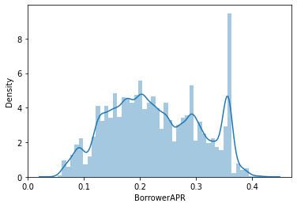

```python
sns.distplot(idf['BorrowerAPR'])
```

There seems to be a spike at 0.35 and smaller spike at 0.29

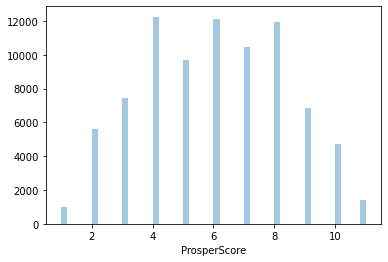

```python
sns.distplot(idf['ProsperScore'],kde=False)
```

The distribution seems to be almost normal with "4","6", and "8" being the highest.

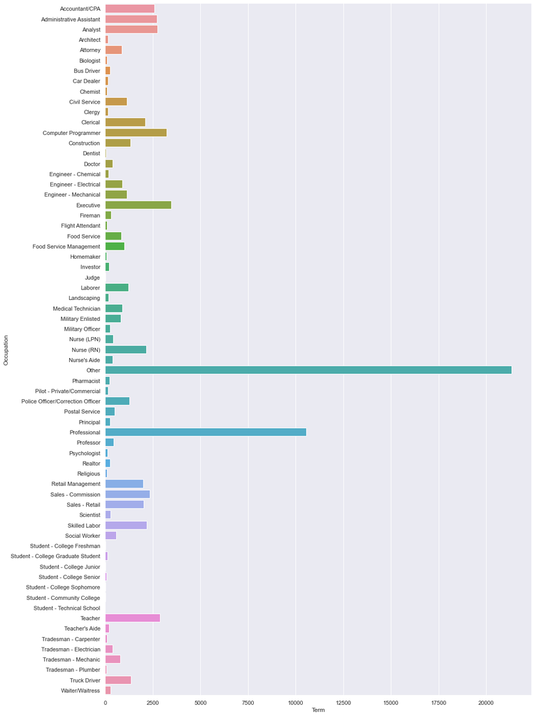

```python
occ=idf.groupby("Occupation").count().reset_index()
sns.set(rc={'figure.figsize':(15,25)})
ax = sns.barplot(x="Term", y="Occupation", data=occ, ci=None,orient='h' )
```

"Other" and "Professional" are the highest occupations, but they are both too large and for that, removing them will make the plot better to be seen

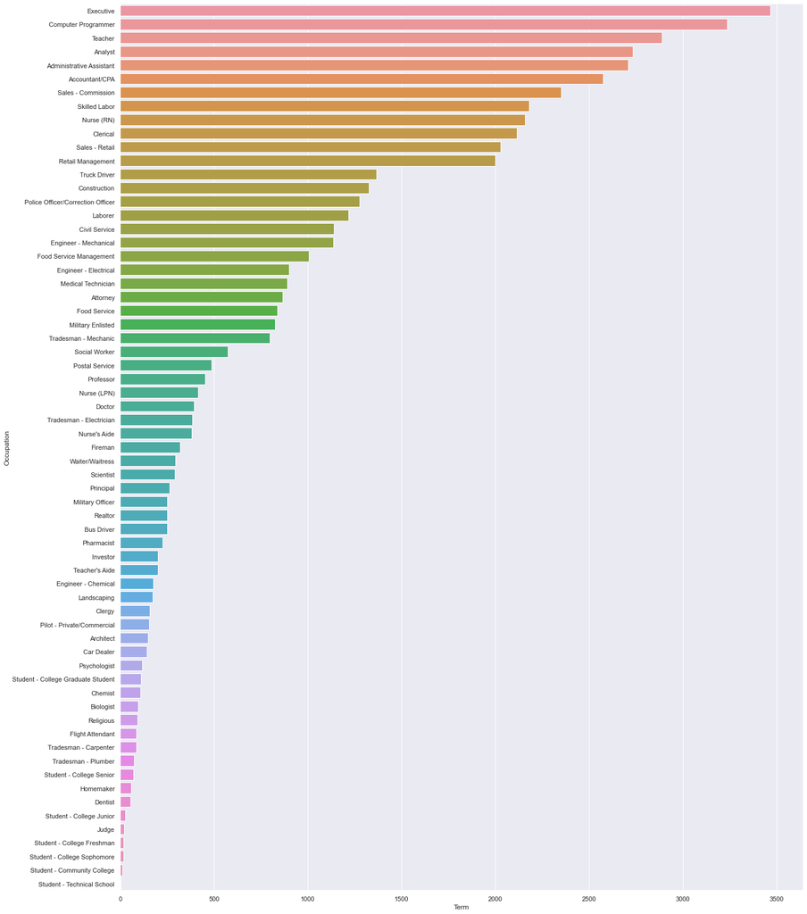

```python
sub_occ=idf.groupby("Occupation").count()
sub_occ.drop(['Other',"Professional"],inplace=True)
sub_occ=sub_occ.sort_values(['Term'],ascending=False).reset_index()
sns.set(rc={'figure.figsize':(21,28)})
ax = sns.barplot(x="Term", y="Occupation", data=sub_occ )
```

```python
sub_occ
```

|  | Occupation | BorrowerAPR | ProsperScore | IncomeRange | StatedMonthlyIncome | LoanOriginalAmount | AvailableBankcardCredit | Term |
| --- | --- | --- | --- | --- | --- | --- | --- | --- |
| 0 | Executive | 3468 | 3468 | 3468 | 3468 | 3468 | 3468 | 3468 |
| 1 | Computer Programmer | 3236 | 3236 | 3236 | 3236 | 3236 | 3236 | 3236 |
| 2 | Teacher | 2888 | 2888 | 2888 | 2888 | 2888 | 2888 | 2888 |
| 3 | Analyst | 2735 | 2735 | 2735 | 2735 | 2735 | 2735 | 2735 |
| 4 | Administrative Assistant | 2708 | 2708 | 2708 | 2708 | 2708 | 2708 | 2708 |
| ... | ... | ... | ... | ... | ... | ... | ... | ... |
| 60 | Judge | 22 | 22 | 22 | 22 | 22 | 22 | 22 |
| 61 | Student - College Freshman | 17 | 17 | 17 | 17 | 17 | 17 | 17 |
| 62 | Student - College Sophomore | 16 | 16 | 16 | 16 | 16 | 16 | 16 |
| 63 | Student - Community College | 10 | 10 | 10 | 10 | 10 | 10 | 10 |
| 64 | Student - Technical School | 2 | 2 | 2 | 2 | 2 | 2 | 2 |

65 rows × 8 columns

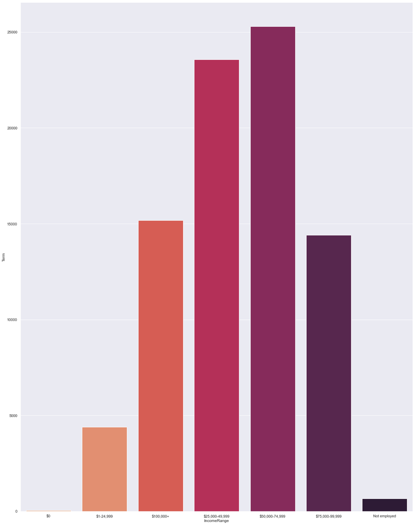

```python
income_r=idf.groupby("IncomeRange").count().reset_index()
sns.set(rc={'figure.figsize':(21,28)})
ax = sns.barplot(x="IncomeRange", y="Term", data=income_r,palette="rocket_r" )
```

The data looks a bit left skewed

```python
income_r
```

|  | IncomeRange | BorrowerAPR | ProsperScore | Occupation | StatedMonthlyIncome | LoanOriginalAmount | AvailableBankcardCredit | Term |
| --- | --- | --- | --- | --- | --- | --- | --- | --- |
| 0 | $0 | 45 | 45 | 45 | 45 | 45 | 45 | 45 |
| 1 | $1-24,999 | 4392 | 4392 | 4392 | 4392 | 4392 | 4392 | 4392 |
| 2 | $100,000+ | 15166 | 15166 | 15166 | 15166 | 15166 | 15166 | 15166 |
| 3 | $25,000-49,999 | 23574 | 23574 | 23574 | 23574 | 23574 | 23574 | 23574 |
| 4 | $50,000-74,999 | 25293 | 25293 | 25293 | 25293 | 25293 | 25293 | 25293 |
| 5 | $75,000-99,999 | 14401 | 14401 | 14401 | 14401 | 14401 | 14401 | 14401 |
| 6 | Not employed | 649 | 649 | 649 | 649 | 649 | 649 | 649 |

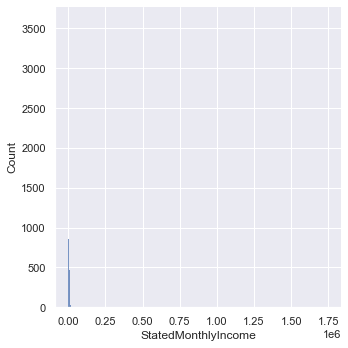

```python
pd.set_option('display.float_format', lambda x: '%.3f' % x)
sns.displot(idf['StatedMonthlyIncome'])
```

```python
idf['StatedMonthlyIncome'].sort_values
```

```
<bound method Series.sort_values of 1        6125.000
3        2875.000
4        9583.333
5        8333.333
6        2083.333
           ...
113932   4333.333
113933   8041.667
113934   2875.000
113935   3875.000
113936   4583.333
Name: StatedMonthlyIncome, Length: 83520, dtype: float64>
```

There are a lot of zeros which makes the plot unreadable, those will be removed for a better plot

```python
stated_rev=idf.query('StatedMonthlyIncome > 1000')['StatedMonthlyIncome'].sort_values()
```

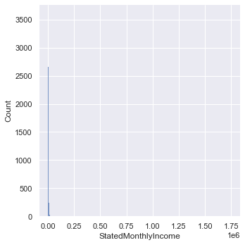

```python
sns.displot(stated_rev)
```

The zeros were not the problem but the larger number got turned into scientific notations, we can solve this problem by treating them as outliers and removing them from the graph

```python
stated_rev.shape
```

```
(82026,)
```

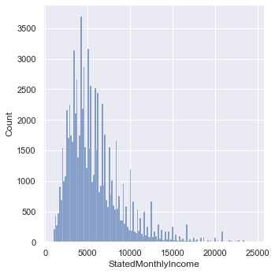

```python
sns.displot(stated_rev.head(81500))
```

The graph is right skewed showing that people who take more loans are the ones with less income

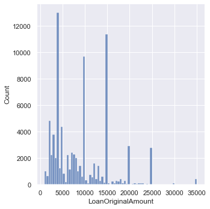

```python
sns.set(rc={'figure.figsize':(11.7,8.27)})
sns.displot(idf['LoanOriginalAmount'])
```

There is a spike at around 4000, 10000, and 15000

```python
idf.groupby('LoanOriginalAmount').count().sort_values(by='Term',ascending=False)
```

| LoanOriginalAmount | BorrowerAPR | ProsperScore | Occupation | IncomeRange | StatedMonthlyIncome | AvailableBankcardCredit | Term |
| --- | --- | --- | --- | --- | --- | --- | --- |
| 4000 | 12753 | 12753 | 12753 | 12753 | 12753 | 12753 | 12753 |
| 15000 | 11306 | 11306 | 11306 | 11306 | 11306 | 11306 | 11306 |
| 10000 | 9585 | 9585 | 9585 | 9585 | 9585 | 9585 | 9585 |
| 2000 | 4537 | 4537 | 4537 | 4537 | 4537 | 4537 | 4537 |
| 5000 | 4181 | 4181 | 4181 | 4181 | 4181 | 4181 | 4181 |
| ... | ... | ... | ... | ... | ... | ... | ... |
| 6815 | 1 | 1 | 1 | 1 | 1 | 1 | 1 |
| 6790 | 1 | 1 | 1 | 1 | 1 | 1 | 1 |
| 6789 | 1 | 1 | 1 | 1 | 1 | 1 | 1 |
| 6785 | 1 | 1 | 1 | 1 | 1 | 1 | 1 |
| 8578 | 1 | 1 | 1 | 1 | 1 | 1 | 1 |

1923 rows × 7 columns

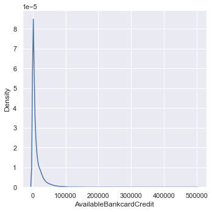

```python
sns.displot(idf,x='AvailableBankcardCredit',kind="kde")
```

```python
idf['AvailableBankcardCredit'].describe()
```

```
count    83520.000
mean     11424.714
std      18612.821
min          0.000
25%       1150.000
50%       4597.000
75%      13967.000
max     498374.000
Name: AvailableBankcardCredit, dtype: float64
```

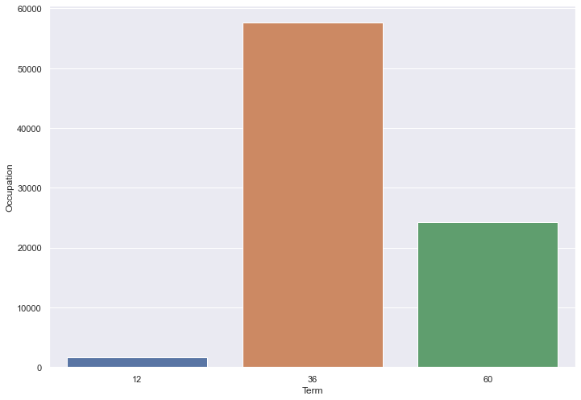

```python
term_count=idf.groupby('Term').count().reset_index()
sns.barplot(data=term_count,x='Term',y='Occupation')
```

```python
term_count
```

|  | Term | BorrowerAPR | ProsperScore | Occupation | IncomeRange | StatedMonthlyIncome | LoanOriginalAmount | AvailableBankcardCredit |
| --- | --- | --- | --- | --- | --- | --- | --- | --- |
| 0 | 12 | 1613 | 1613 | 1613 | 1613 | 1613 | 1613 | 1613 |
| 1 | 36 | 57621 | 57621 | 57621 | 57621 | 57621 | 57621 | 57621 |
| 2 | 60 | 24286 | 24286 | 24286 | 24286 | 24286 | 24286 | 24286 |

"36 months" is the the most common term for loans, while "60 months" is the second most common and " 12 month" being the least.

> Make sure that, after every plot or related series of plots, that you include a Markdown cell with comments about what you observed, and what you plan on investigating next.

### Discuss the distribution(s) of your variable(s) of interest. Were there any unusual points? Did you need to perform any transformations?

The income range of 50k-75k was the most common, although I expected the reverse of that.

### Of the features you investigated, were there any unusual distributions? Did you perform any operations on the data to tidy, adjust, or change the form of the data? If so, why did you do this?

I had to use groupby for some of the data in order to check their disterbution, remove some column for easier analysis, and remove zeros since it may have affected the data -those rows were only removed in the plot and are still present in the data-.

## Bivariate Exploration

> In this section, investigate relationships between pairs of variables in your data. Make sure the variables that you cover here have been introduced in some fashion in the previous section (univariate exploration).

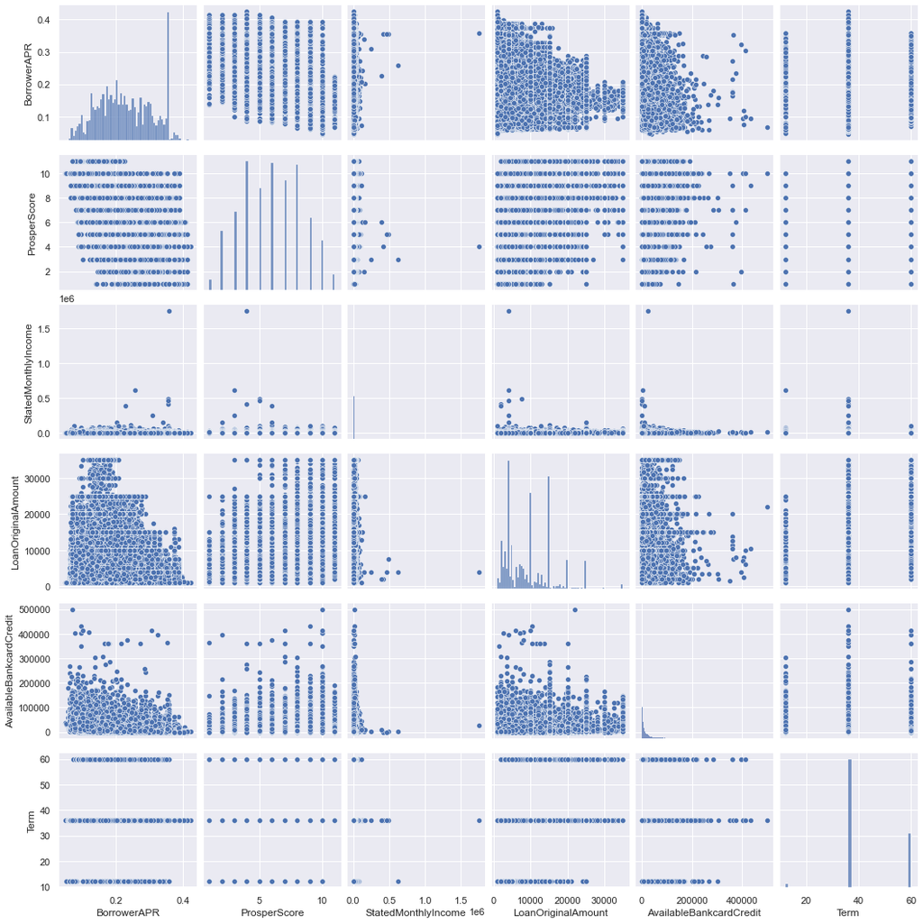

```python
sns.pairplot(idf)
```

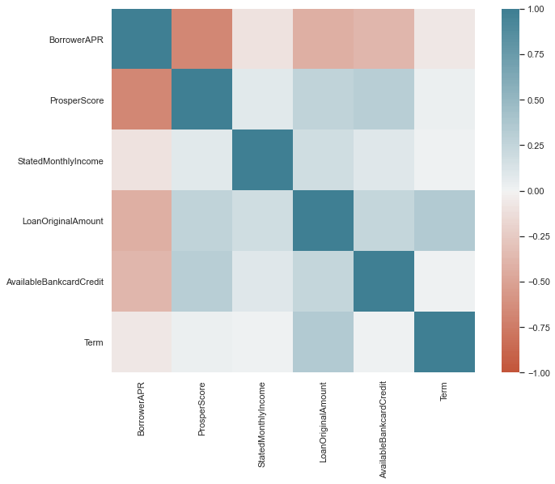

```python
corr = idf.corr()
ax = sns.heatmap(
    corr,
    vmin=-1, vmax=1, center=0,
    cmap=sns.diverging_palette(20, 220, n=200),
    square=True
)
```

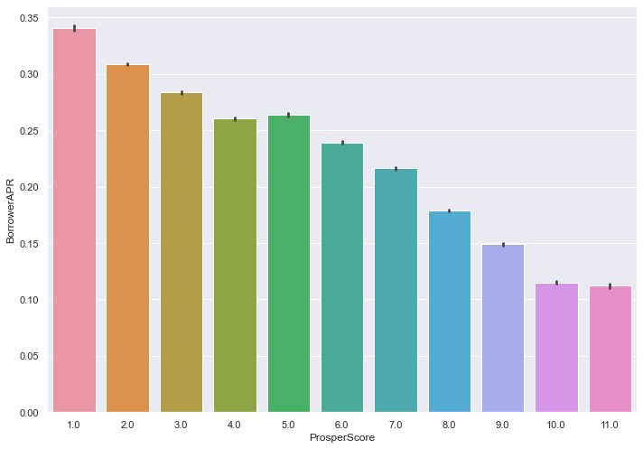

```python
 sns.barplot(x="ProsperScore", y="BorrowerAPR", data=idf);
```

```python
idf['ProsperScore'].corr(idf['BorrowerAPR'])
```

```
-0.6695101130030133
```

It is obvious that as the prosper score increases the annual percentage rate decreases, which is confirmed by the heatmap above.

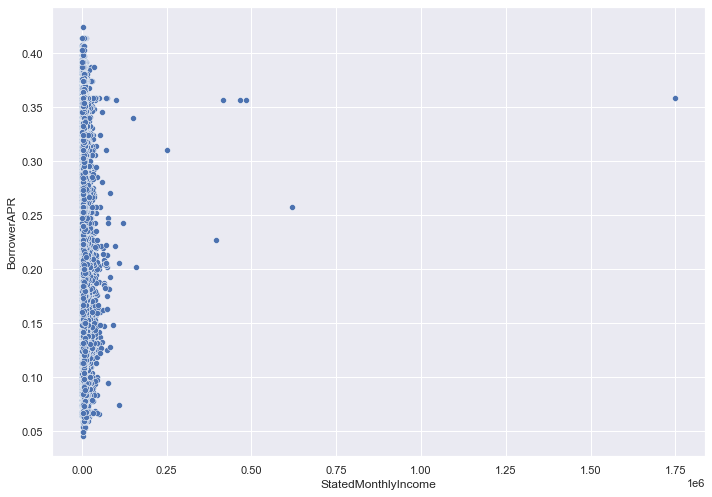

```python
sns.scatterplot(data=idf, x="StatedMonthlyIncome", y="BorrowerAPR");
```

There seems to be some outliers that are messing with the plot; those will be removed

```python
idf.sort_values(by="StatedMonthlyIncome").tail(10)
```

|  | BorrowerAPR | ProsperScore | Occupation | IncomeRange | StatedMonthlyIncome | LoanOriginalAmount | AvailableBankcardCredit | Term |
| --- | --- | --- | --- | --- | --- | --- | --- | --- |
| 59298 | 0.242 | 6.000 | Other | $100,000+ | 120833.333 | 15000 | 14680.000 | 36 |
| 45028 | 0.340 | 2.000 | Nurse (RN) | $100,000+ | 150000.000 | 4000 | 2089.000 | 36 |
| 80075 | 0.202 | 6.000 | Attorney | $100,000+ | 158333.333 | 25000 | 9817.000 | 36 |
| 82831 | 0.310 | 3.000 | Other | $100,000+ | 250000.000 | 4000 | 2331.000 | 36 |
| 113270 | 0.227 | 6.000 | Other | $100,000+ | 394400.000 | 2000 | 10012.000 | 36 |
| 8066 | 0.356 | 4.000 | Police Officer/Correction Officer | $100,000+ | 416666.667 | 2000 | 0.000 | 36 |
| 57133 | 0.356 | 5.000 | Other | $100,000+ | 466666.667 | 4000 | 0.000 | 36 |
| 17411 | 0.356 | 5.000 | Professional | $100,000+ | 483333.333 | 7500 | 2114.000 | 36 |
| 53014 | 0.258 | 3.000 | Other | $100,000+ | 618547.833 | 4000 | 3091.000 | 12 |
| 53167 | 0.358 | 4.000 | Professional | $100,000+ | 1750002.917 | 4000 | 26168.000 | 36 |

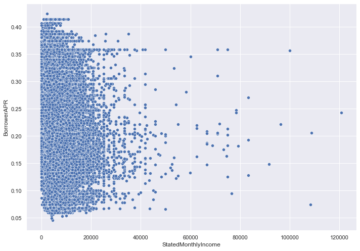

```python
sns.scatterplot(data=idf.query('StatedMonthlyIncome<120834'), x="StatedMonthlyIncome", y="BorrowerAPR");
```

```python
idf['StatedMonthlyIncome'].corr(idf['BorrowerAPR'])
```

```
-0.09445870584799788
```

Unfortunately, no correlation can be made from the scatter plot.

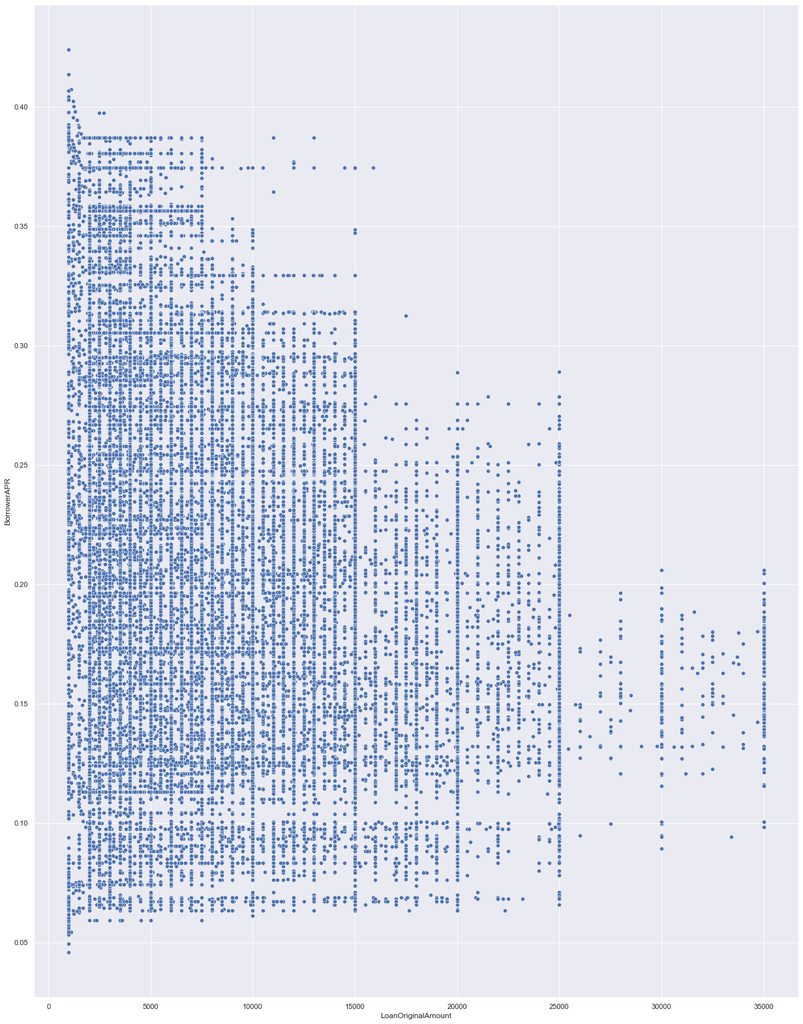

```python
sns.scatterplot(data=idf, x="LoanOriginalAmount", y="BorrowerAPR");
```

```python
idf['LoanOriginalAmount'].corr(idf['BorrowerAPR'])
```

```
-0.4276430749150432
```

The relation between the LoanOriginalAmount and the BorrowerAPR is negetive, although not strong.

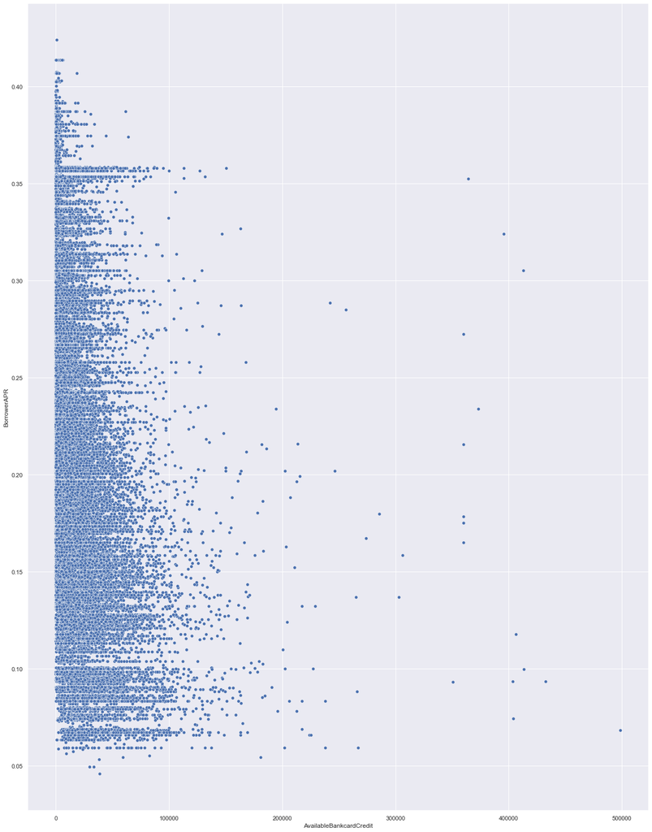

```python
sns.scatterplot(data=idf, x="AvailableBankcardCredit", y="BorrowerAPR");
```

```python
idf['AvailableBankcardCredit'].corr(idf['BorrowerAPR'])
```

```
-0.37246648928724896
```

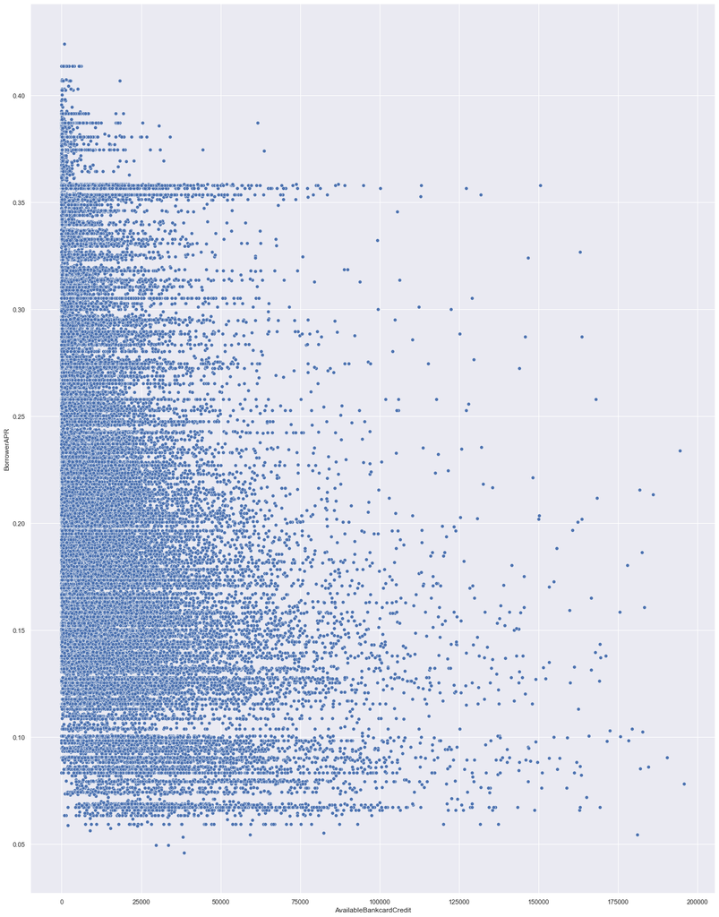

```python
sns.scatterplot(data=idf.query('AvailableBankcardCredit<200000'), x="AvailableBankcardCredit", y="BorrowerAPR");
```

```python
idf.query('AvailableBankcardCredit<200000')['AvailableBankcardCredit'].corr(idf.query('AvailableBankcardCredit<200000')['BorrowerAPR'])
```

```
-0.3934254190113852
```

There is a weak corelation between AvailableBankcardCredit and BorrowerAPR even after removeing the outliers

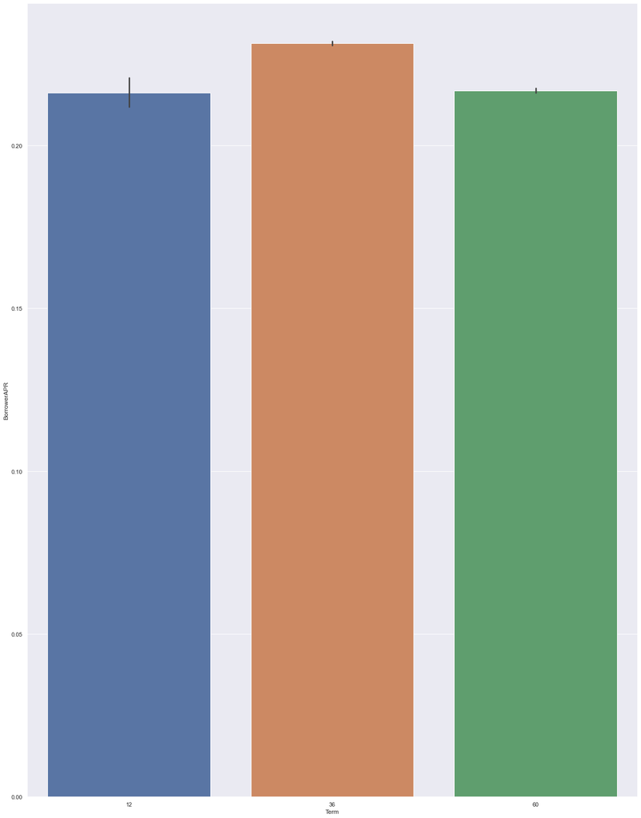

```python
 sns.barplot(x="Term", y="BorrowerAPR", data=idf);
```

```python
idf.groupby('Term').mean()
```

| Term | BorrowerAPR | ProsperScore | StatedMonthlyIncome | LoanOriginalAmount | AvailableBankcardCredit |
| --- | --- | --- | --- | --- | --- |
| 12 | 0.216 | 6.564 | 6890.335 | 4696.587 | 17719.445 |
| 36 | 0.231 | 5.885 | 5865.404 | 7836.953 | 10899.446 |
| 60 | 0.217 | 6.114 | 6145.715 | 12402.041 | 12252.889 |

We can see that 36 months tends to have the highest BorrowerAPR while 12 months and 60 months are almost the same -12 months:0.216, 60 months: 0.217-.

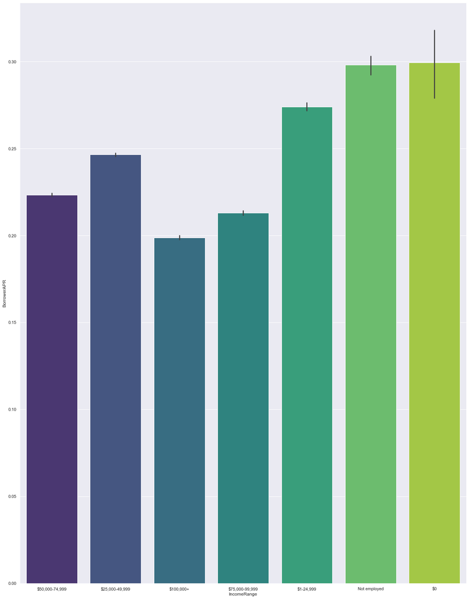

```python
sns.barplot(x="IncomeRange", y="BorrowerAPR", data=idf,palette='viridis');
```

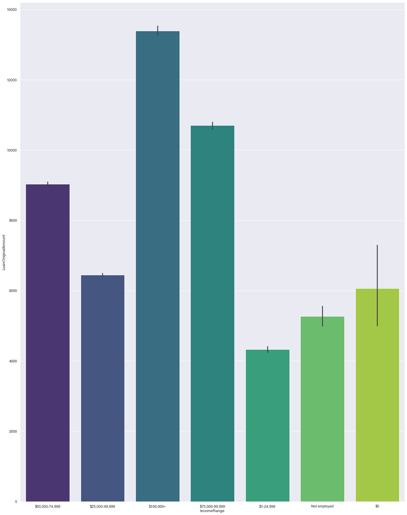

```python
sns.barplot(data=idf,y='LoanOriginalAmount',x='IncomeRange',palette='viridis');
```

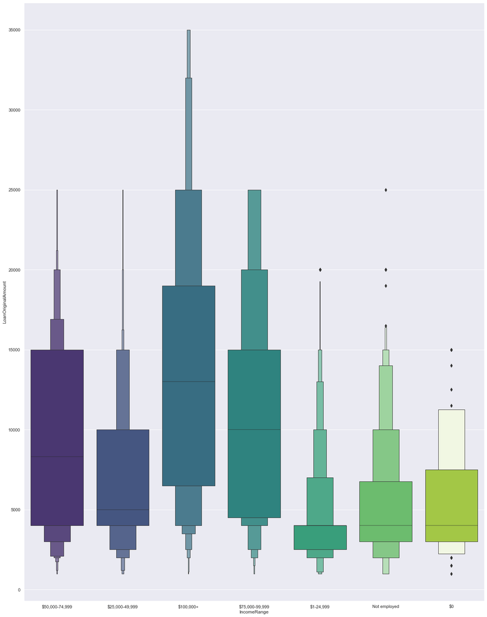

```python
sns.boxenplot(data=idf,y='LoanOriginalAmount',x='IncomeRange',palette='viridis');
```

As expected the reason for people with lower income recieving a higher interest rate is because people with less income tend to borrow less money resulting in higher interest rate.

### Talk about some of the relationships you observed in this part of the investigation. How did the feature(s) of interest vary with other features in the dataset?

It is obvious that as the prosper score increases the annual percentage rate decreases. There was no corelation between StatedMonthlyIncome and BorrowerAPR .The relation between the LoanOriginalAmount and the BorrowerAPR is negetive, although not strong. There is a weak corelation between AvailableBankcardCredit and BorrowerAPR even after removeing the outliers.

## Multivariate Exploration

> Create plots of three or more variables to investigate your data even further. Make sure that your investigations are justified, and follow from your work in the previous sections.

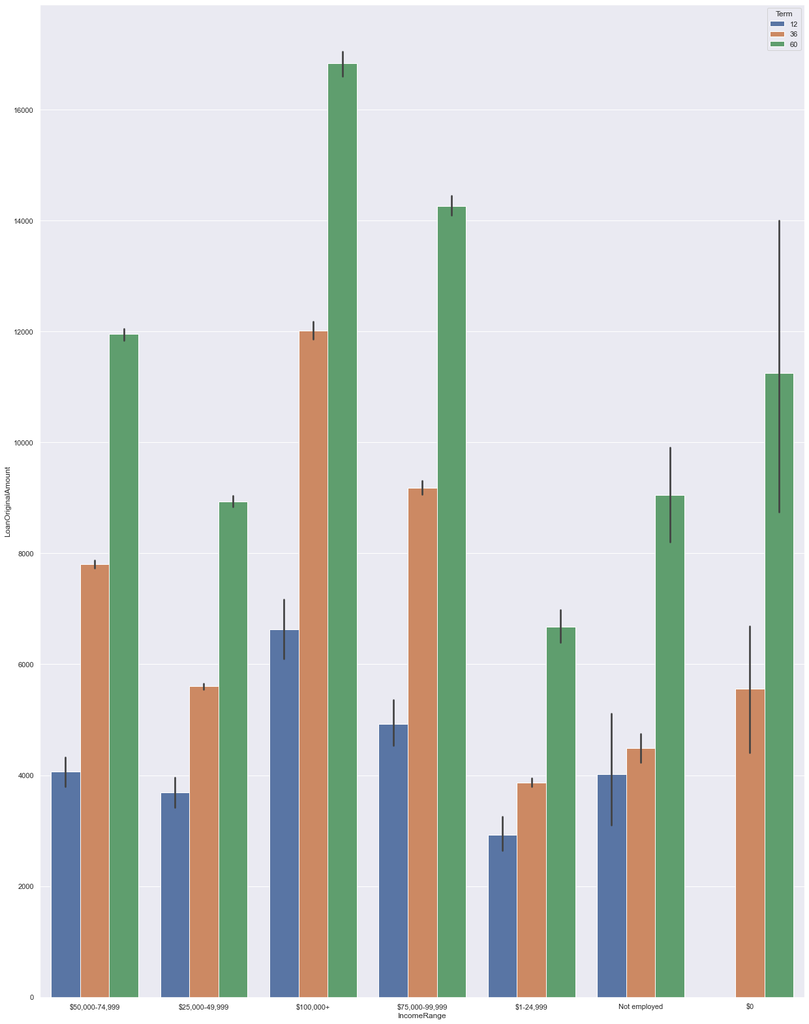

```python
sns.barplot(x="IncomeRange", y="LoanOriginalAmount", hue="Term", data=idf)
```

```python
idf.query('IncomeRange=="$0"').groupby('Term').count()
```

| Term | BorrowerAPR | ProsperScore | Occupation | IncomeRange | StatedMonthlyIncome | LoanOriginalAmount | AvailableBankcardCredit |
| --- | --- | --- | --- | --- | --- | --- | --- |
| 36 | 41 | 41 | 41 | 41 | 41 | 41 | 41 |
| 60 | 4 | 4 | 4 | 4 | 4 | 4 | 4 |

For all income ranges, the longer the term the more money will be borrowed. There was no money borrowed for 12 months for people with the 0$ income

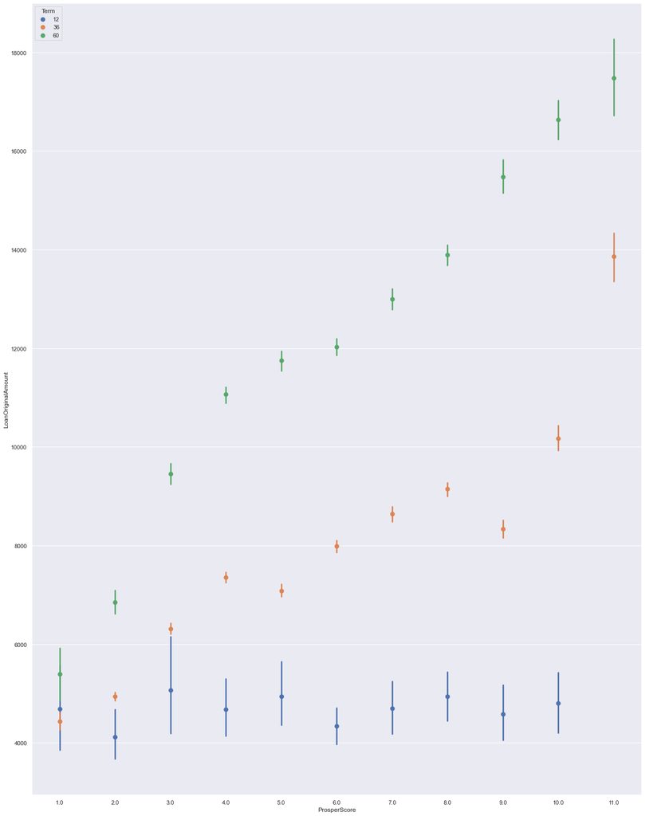

```python
sns.pointplot(x = "ProsperScore",
              y = "LoanOriginalAmount",
              linestyles = '',
              hue = "Term",
              data = idf)
```

As the prosper score increases, the amount of mony borrowed increase, except for the 12 months which seems to almost not change.

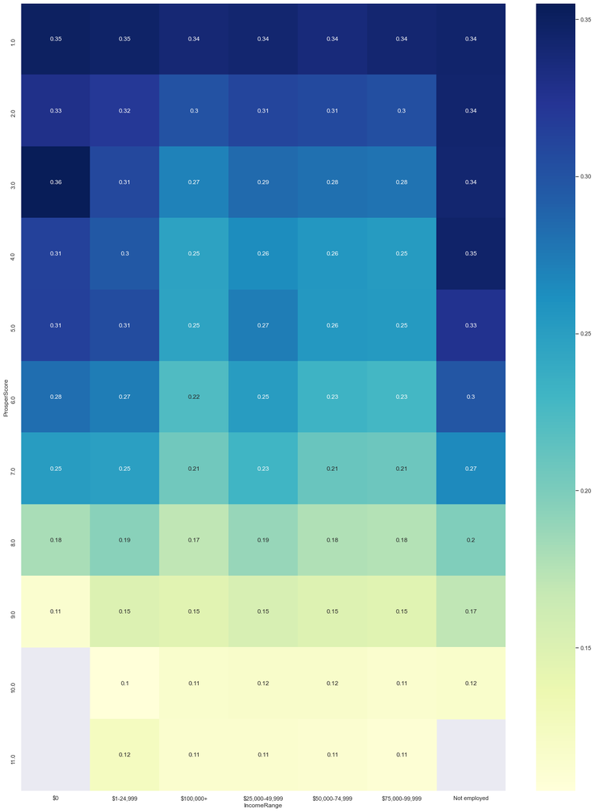

```python
heatdf=idf.groupby(['ProsperScore', 'IncomeRange']).mean().reset_index()
heatdf
heatdf=heatdf.pivot(index="ProsperScore", columns="IncomeRange", values="BorrowerAPR")
sns.heatmap(heatdf, annot = True,cmap="YlGnBu")
```

https://stackoverflow.com/questions/39041865/three-variables-as-heatmap

Almost always the higher income range will have a lower BorrowerAPR in any ProsperScore.

### Talk about some of the relationships you observed in this part of the investigation. Were there features that strengthened each other in terms of looking at your feature(s) of interest?

For all income ranges, the longer the term the more money will be borrowed. Almost always the higher income range will have a lower BorrowerAPR in any ProsperScore.

### Were there any interesting or surprising interactions between features?

As the prosper score increases, the amount of mony borrowed increase, except for the 12 months which seems to almost not change.